# 球队分析

2022-12-22

# Variances

EFG_O: Effective Field Goal Percentage Shot  
EFG_D: Effective Field Goal Percentage Allowed  
TOR: Turnover Percentage Allowed (Turnover Rate)  
TORD: Turnover Percentage Committed (Steal Rate)  
ORB: Offensive Rebound Rate  
DRB: Offensive Rebound Rate Allowed  
FTR : Free Throw Rate (How often the given team shoots Free Throws)  
FTRD: Free Throw Rate Allowed  
2P_O: Two-Point Shooting Percentage  
2P_D: Two-Point Shooting Percentage Allowed  
3P_O: Three-Point Shooting Percentage  
3P_D: Three-Point Shooting Percentage Allowed  
ADJ_T: Adjusted Tempo (An estimate of the tempo (possessions per 40 minutes) a team would have against the team that wants to play at an average Division I tempo)  
WAB: Wins Above Bubble (The bubble refers to the cut off between making the NCAA March Madness Tournament and not making it)

# Read Data

```r
cbb <- read.csv('cbb.csv')
print(colnames(cbb))
```

```
##  [1] "TEAM"       "CONF"       "G"          "W"          "ADJOE"
##  [6] "ADJDE"      "BARTHAG"    "EFG_O"      "EFG_D"      "TOR"
## [11] "TORD"       "ORB"        "DRB"        "FTR"        "FTRD"
## [16] "X2P_O"      "X2P_D"      "X3P_O"      "X3P_D"      "ADJ_T"
## [21] "WAB"        "POSTSEASON" "SEED"       "YEAR"
```

# EDA

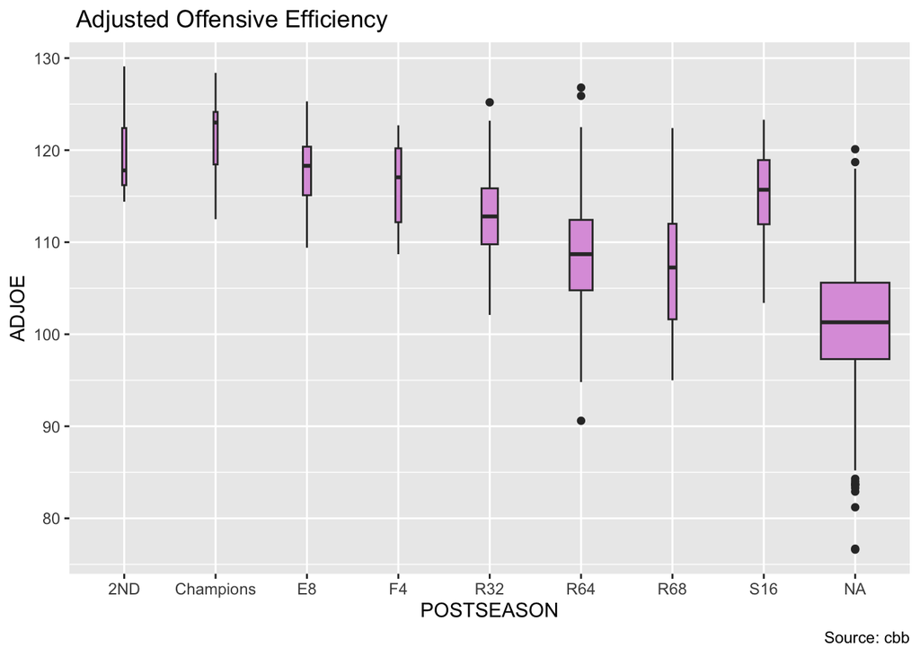

```r
box1 <- ggplot(cbb, aes(POSTSEASON, ADJOE))
box1 + geom_boxplot(varwidth=T, fill="plum") +
     labs(title=" Adjusted Offensive Efficiency ",
          caption="Source: cbb",
          x="POSTSEASON",
          y="ADJOE")
```

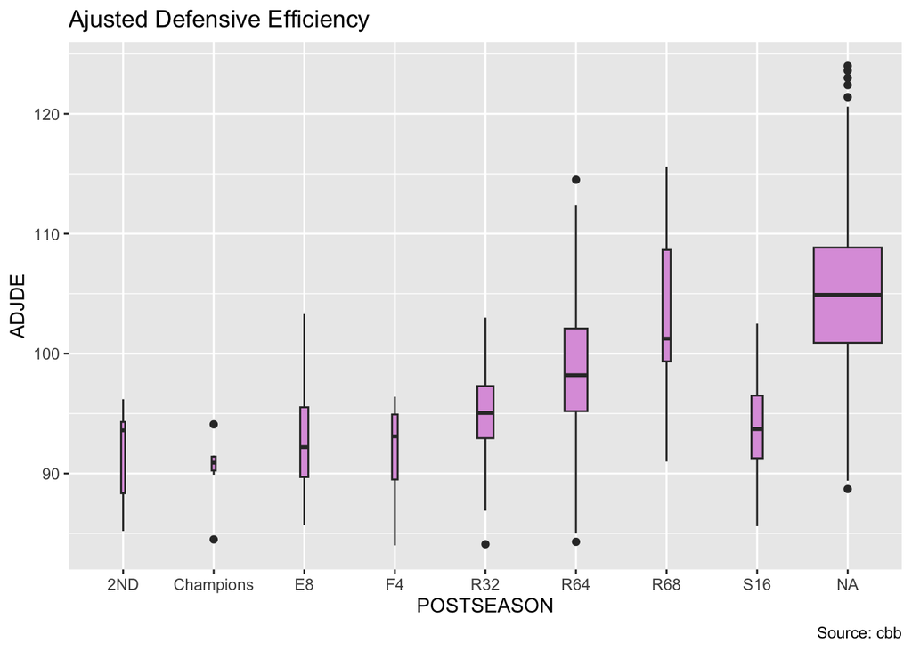

```r
box2 <- ggplot(cbb, aes(POSTSEASON, ADJDE))
box2 + geom_boxplot(varwidth=T, fill="plum") +
     labs(title="Ajusted Defensive Efficiency ",
          caption="Source: cbb",
          x="POSTSEASON",
          y="ADJDE")
```

# Correlation Coefficient Matrix

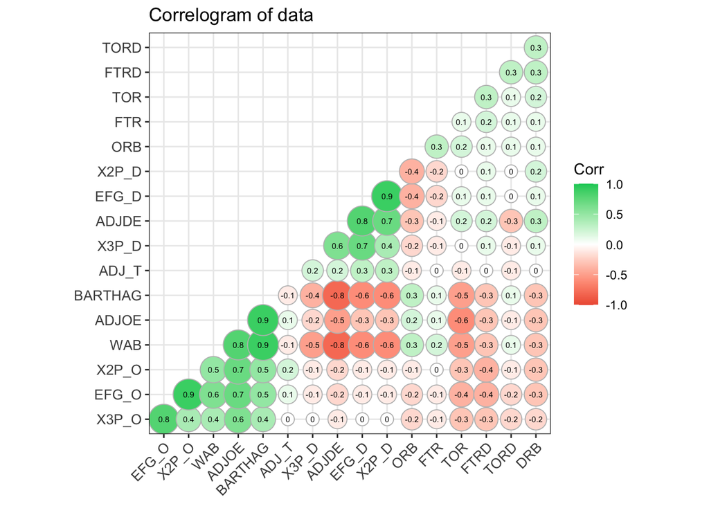

```r
corr <- round(cor(cbb[, 5:21]), 1)
ggcorrplot(corr, hc.order = TRUE,
           type = "lower",
           lab = TRUE,
           lab_size = 2,
           tl.cex = 10,
           method="circle",
           colors = c("tomato2", "white", "springgreen3"),
           title="Correlogram of data",
           ggtheme=theme_bw)
```

WAB, X2P_O, EFG_O, and X3P_O are strongly positive related to ADJOE. While TOR is negative related to ADJOE, and EFG_D, X2P_D, FTRD and DRB are a little negative related to ADJOE.

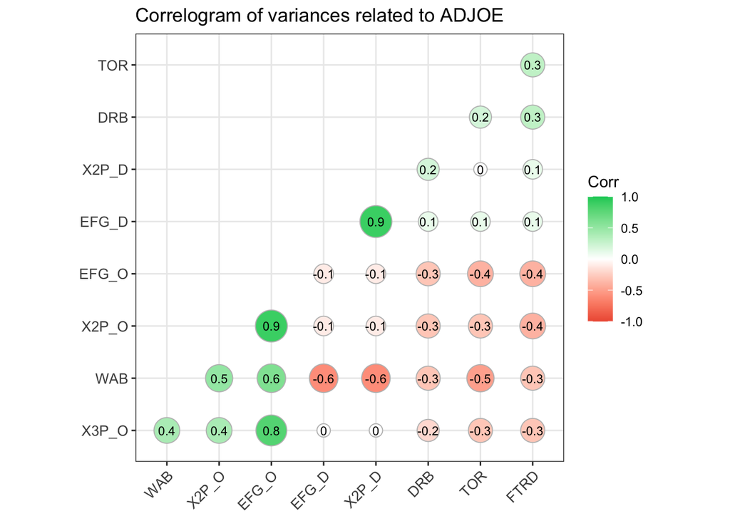

```r
corr1 <- round(cor(cbb[, c('WAB', 'X2P_O', 'EFG_O', 'X3P_O', 'TOR',                      'EFG_D', 'X2P_D', 'FTRD', 'DRB')]), 1)
ggcorrplot(corr1, hc.order = TRUE,
           type = "lower",
           lab = TRUE,
           lab_size = 3,
           tl.cex = 10,
           method="circle",
           colors = c("tomato2", "white", "springgreen3"),
           title="Correlogram of variances related to ADJOE",
           ggtheme=theme_bw)
```

For ADJDE, X2P_D, X3P_D and EFG_D are strongly positive related to ADJDE, while DRB is a little positive related to ADJDE. On the other hand, WAB are strongly negative related to ADJDE, while ORB and TORD are a little negative related to ADJDE.

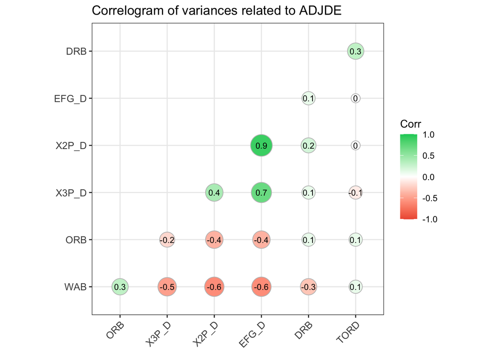

```r
corr2 <- round(cor(cbb[, c('WAB', 'X2P_D', 'X3P_D', 'EFG_D', 'DRB', 'ORB', 'TORD')]), 1)
ggcorrplot(corr2, hc.order = TRUE,
           type = "lower",
           lab = TRUE,
           lab_size = 3,
           tl.cex = 10,
           method="circle",
           colors = c("tomato2", "white", "springgreen3"),
           title="Correlogram of variances related to ADJDE",
           ggtheme=theme_bw)
```

# Regression Analysis

```r
#m1 <- lm(ADJOE~WAB+X2P_O+EFG_O+X3P_O+TOR+EFG_D+X2P_D+FTRD+DRB, data=cbb)
#m2 <- lm(ADJOE~WAB+X2P_O+X3P_O+TOR+X2P_D+FTRD+DRB, data=cbb)
#m6 <- lm(ADJOE~WAB+X2P_O+X3P_O+TOR+X2P_D+ORB+DRB, data=cbb)
#m3 <- lm(ADJOE~WAB+EFG_O+EFG_D+TOR+FTRD+DRB, data=cbb)
#m4 <- lm(ADJOE~WAB+EFG_O+EFG_D+TOR+FTRD+DRB+ORB, data=cbb)
#m5 <- lm(ADJOE~WAB+EFG_O+EFG_D+TOR+DRB+ORB, data=cbb)

m_adjoe <- lm(ADJOE~WAB+EFG_O+EFG_D+TOR+TORD+DRB+ORB+FTR, data=cbb)
summary(m_adjoe)
```

```
##
## Call:
## lm(formula = ADJOE ~ WAB + EFG_O + EFG_D + TOR + TORD + DRB +
##     ORB + FTR, data = cbb)
##
## Residuals:
##     Min      1Q  Median      3Q     Max
## -7.5638 -1.3474  0.0047  1.3460  7.8916
##
## Coefficients:
##              Estimate Std. Error t value Pr(>|t|)
## (Intercept) 48.714530   1.524586  31.953  < 2e-16 ***
## WAB          0.643662   0.013328  48.295  < 2e-16 ***
## EFG_O        0.852157   0.019823  42.988  < 2e-16 ***
## EFG_D        0.469380   0.020902  22.456  < 2e-16 ***
## TOR         -0.857523   0.026328 -32.571  < 2e-16 ***
## TORD        -0.498525   0.021582 -23.099  < 2e-16 ***
## DRB          0.198763   0.015256  13.028  < 2e-16 ***
## ORB          0.389387   0.012900  30.185  < 2e-16 ***
## FTR          0.041582   0.008633   4.817 1.55e-06 ***
## ---
## Signif. codes:  0 '***' 0.001 '**' 0.01 '*' 0.05 '.' 0.1 ' ' 1
##
## Residual standard error: 2.075 on 2446 degrees of freedom
## Multiple R-squared:  0.9212, Adjusted R-squared:  0.9209
## F-statistic:  3573 on 8 and 2446 DF,  p-value: < 2.2e-16
```

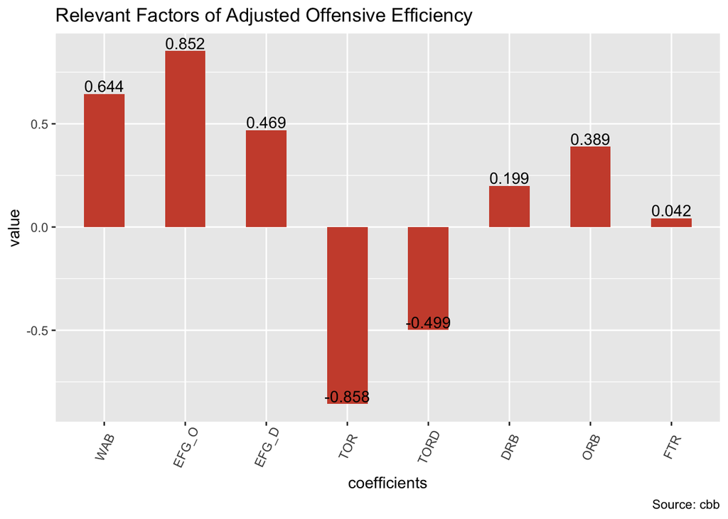

```r
df_adjoe <- data.frame(coefficients=c('WAB', 'EFG_O', 'EFG_D', 'TOR', 'TORD', 'DRB','ORB', 'FTR'), value=c(0.643662, 0.852157, 0.469380, -0.857523, -0.498525, 0.198763, 0.389387, 0.041582))

df_adjoe$coefficients <- factor(df_adjoe$coefficients, levels=df_adjoe$coefficients)

ggplot(df_adjoe, aes(x=coefficients, y=value))+
  geom_bar(stat='identity', width=.5, fill="tomato3")+
  theme(axis.text.x = element_text(angle=65, vjust=0.6))+
  geom_text(aes(label=round(value,3)),
            position = position_dodge2(width = 0.9, preserve = 'single'),
            vjust = -0.2, hjust = 0.5)+
  labs(title="Relevant Factors of Adjusted Offensive Efficiency",
          caption="Source: cbb")
```

According to analysis, EFG_O and TOR are the most two important factors. If we improve 1 point of EFG_O, we can increase almost 0.852 for Adjusted Offensive Efficiency. However, if TOR increase 1 point, the Adjusted Offensive Efficiency will decrease 0.858.

```r
#m1 <- lm(ADJDE~WAB+X2P_D+X3P_D+EFG_D+DRB+ORB+TORD, data=cbb)
#m2 <- lm(ADJDE~WAB+EFG_D+DRB+ORB+TORD, data=cbb)
#m4 <- lm(ADJDE~X2P_D+X3P_D+DRB+ORB+TORD, data=cbb)
#m3 <- lm(ADJDE~WAB+X2P_D+X3P_D+DRB+ORB+TORD, data=cbb)

m_adjde <- lm(ADJDE~WAB+X2P_D+X3P_D+DRB+ORB+TORD+ADJ_T, data=cbb)
summary(m_adjde)
```

```
##
## Call:
## lm(formula = ADJDE ~ WAB + X2P_D + X3P_D + DRB + ORB + TORD +
##     ADJ_T, data = cbb)
##
## Residuals:
##     Min      1Q  Median      3Q     Max
## -8.1145 -1.6764 -0.0272  1.6854  8.8301
##
## Coefficients:
##              Estimate Std. Error t value Pr(>|t|)
## (Intercept) 36.967698   1.548157  23.879  < 2e-16 ***
## WAB         -0.383978   0.009876 -38.881  < 2e-16 ***
## X2P_D        0.798217   0.019768  40.380  < 2e-16 ***
## X3P_D        0.518325   0.023788  21.789  < 2e-16 ***
## DRB          0.423676   0.017917  23.646  < 2e-16 ***
## ORB          0.071006   0.013265   5.353 9.45e-08 ***
## TORD        -0.801261   0.024491 -32.717  < 2e-16 ***
## ADJ_T        0.094749   0.016122   5.877 4.75e-09 ***
## ---
## Signif. codes:  0 '***' 0.001 '**' 0.01 '*' 0.05 '.' 0.1 ' ' 1
##
## Residual standard error: 2.46 on 2447 degrees of freedom
## Multiple R-squared:  0.8617, Adjusted R-squared:  0.8613
## F-statistic:  2178 on 7 and 2447 DF,  p-value: < 2.2e-16
```

[figure not shown]

```r
df_adjde <- data.frame(coefficients=c('WAB', 'X2P_D', 'X3P_D', 'DRB', 'ORB','TORD', 'ADJ_T'), value=c(-0.383978,0.798217,0.518325,-0.423676,0.071006,-0.801261,0.094749))

df_adjde$coefficients <- factor(df_adjde$coefficients, levels=df_adjde$coefficients)

ggplot(df_adjde, aes(x=coefficients, y=value))+
  geom_bar(stat='identity', width=.5, fill="tomato3")+
  theme(axis.text.x = element_text(angle=65, vjust=0.6))+
  geom_text(aes(label=round(value,3)),
            position = position_dodge2(width = 0.9, preserve = 'single'),
            vjust = -0.2, hjust = 0.5)+
  labs(title="Relevant Factors of Adjusted Defensive Efficiency",
          caption="Source: cbb")
```

# North Carolina

```r
summary(cbb[,c('ADJOE', 'ADJDE', 'WAB', 'EFG_O', 'EFG_D', 'TOR', 'TORD', 'DRB','ORB', 'FTR')])
```

```
##      ADJOE           ADJDE            WAB              EFG_O
##  Min.   : 76.6   Min.   : 84.0   Min.   :-25.200   Min.   :39.20
##  1st Qu.: 98.3   1st Qu.: 98.5   1st Qu.:-13.000   1st Qu.:47.75
##  Median :103.0   Median :103.5   Median : -8.300   Median :49.70
##  Mean   :103.3   Mean   :103.3   Mean   : -7.802   Mean   :49.81
##  3rd Qu.:108.0   3rd Qu.:107.9   3rd Qu.: -3.150   3rd Qu.:51.90
##  Max.   :129.1   Max.   :124.0   Max.   : 13.100   Max.   :59.80
##      EFG_D           TOR             TORD            DRB             ORB
##  Min.   :39.6   Min.   :11.90   Min.   :10.20   Min.   :18.40   Min.   :15.00
##  1st Qu.:48.0   1st Qu.:17.30   1st Qu.:17.20   1st Qu.:27.90   1st Qu.:27.10
##  Median :50.0   Median :18.70   Median :18.60   Median :30.00   Median :29.90
##  Mean   :50.0   Mean   :18.76   Mean   :18.69   Mean   :30.08   Mean   :29.88
##  3rd Qu.:52.0   3rd Qu.:20.10   3rd Qu.:20.10   3rd Qu.:32.20   3rd Qu.:32.60
##  Max.   :59.5   Max.   :27.10   Max.   :28.50   Max.   :40.40   Max.   :43.60
##       FTR
##  Min.   :21.60
##  1st Qu.:32.40
##  Median :35.80
##  Mean   :35.99
##  3rd Qu.:39.50
##  Max.   :58.60
```

```r
summary(cbb[which(cbb$TEAM=='North Carolina'),c('ADJOE', 'ADJDE', 'WAB', 'EFG_O', 'EFG_D', 'TOR', 'TORD', 'DRB','ORB', 'FTR')])
```

```
##      ADJOE           ADJDE            WAB             EFG_O
##  Min.   :111.6   Min.   :91.40   Min.   : 2.500   Min.   :49.30
##  1st Qu.:116.5   1st Qu.:92.00   1st Qu.: 5.350   1st Qu.:50.75
##  Median :120.1   Median :93.00   Median : 7.100   Median :51.70
##  Mean   :118.5   Mean   :93.59   Mean   : 6.757   Mean   :51.43
##  3rd Qu.:120.8   3rd Qu.:94.80   3rd Qu.: 8.500   3rd Qu.:52.30
##  Max.   :123.3   Max.   :97.10   Max.   :10.000   Max.   :52.90
##      EFG_D            TOR             TORD            DRB
##  Min.   :45.40   Min.   :15.40   Min.   :16.30   Min.   :22.80
##  1st Qu.:47.50   1st Qu.:16.45   1st Qu.:17.95   1st Qu.:25.25
##  Median :48.10   Median :16.90   Median :18.30   Median :30.00
##  Mean   :47.94   Mean   :16.83   Mean   :18.56   Mean   :28.20
##  3rd Qu.:48.50   3rd Qu.:17.20   3rd Qu.:18.95   3rd Qu.:31.25
##  Max.   :50.10   Max.   :18.20   Max.   :21.50   Max.   :31.60
##       ORB             FTR
##  Min.   :34.60   Min.   :28.00
##  1st Qu.:36.35   1st Qu.:29.20
##  Median :38.10   Median :32.30
##  Mean   :38.20   Mean   :33.01
##  3rd Qu.:40.35   3rd Qu.:34.75
##  Max.   :41.30   Max.   :42.90
```

For North Carolina, they are very good at ADJOE. The minimum ADJOE of North Carolina is even higher than 3rd Qu of all teams, which is a very high score in NCAA. According to the model, EFG_O and TOR are the two most important factors that effect ADJOE. North Carolina’s mean EFG_O is higher than most of teams’, and mean TOR is lower than most of teams’.